# Developing your research outline

PHRM7021

Adam La Caze

## Objectives

The objectives of the module are:

1. Critically appraise and synthesise the current evidence
2. Identify a gap in practice or knowledge that can be addressed through research
3. Develop focused, feasible, answerable research questions
4. Communicate your synthesis of the evidence and focused research questions to a knowledgeable, non-expert audience

These notes focus on objectives 2–4.

## The overall process

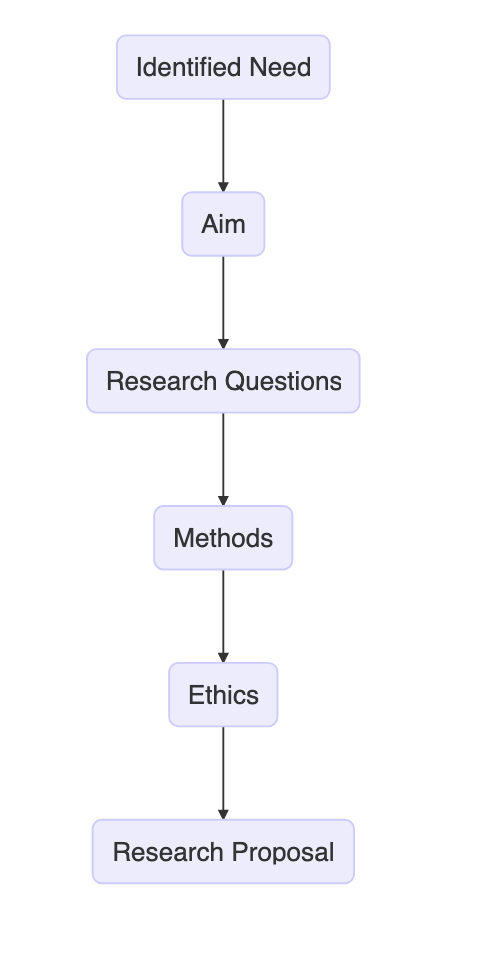

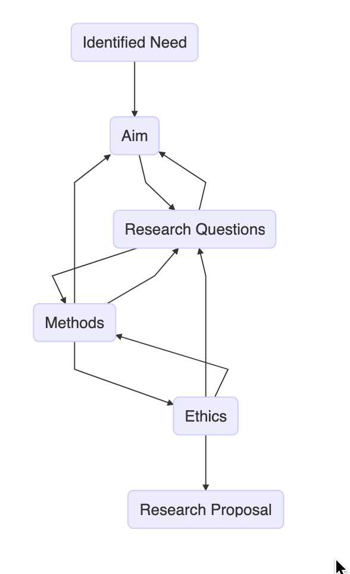

## Developing your research outline (pitch)

- No more than two-pages. Less is more.
- The audience for your research outline is you (clarifying and documenting your ideas), potential collaborators and anyone you might need to involve to get the project done.

## Developing your research outline (pitch)

1. Identifying a need
2. Aim
3. Asking a focused research question

## Identifying a need

- Targeted
- You need to make an argument for
  - Your interpretation of the literature
  - The need for the research, and
  - The approach you are going to take

## Aim

- The aim communicates the purpose of the study
- It needs to “fall out” of the critical synthesis
- Wording is broader than the research question

## Examples

- Foot et al. (2017) provides an aim at the end of the introduction that is a purpose statement.
- Krass et al. (2017) provides ‘Trial Objectives’ and ‘Hypotheses’ rather than ‘Aims’ and ‘Research Question’—but they are achieving similar ends.

## Asking a focused research question

- Your aim should lead directly to your research question.
- Your research question needs to be:
1. Important (it needs to make a contribution)
2. Feasible
3. Answerable
4. Ethical

## Build the research question

The research question should make clear: who are the participants? what comparisons are being made? what will you measure over what time frame?

Consider using the PICOT framework

- Participants
- Intervention (exposure)
- Control (comparison)
- Outcome
- Time

## References

Foot, Holly, Christopher Freeman, Karla Hemming, Ian Scott, Ian D. Coombes, Ian D. Williams, Luke Connelly, et al. 2017. “Reducing Medical Admissions into Hospital Through Optimising Medicines (REMAIN HOME) Study: Protocol for a Stepped-Wedge, Cluster-Randomised Trial.” *BMJ Open* 7 (4): 1–9. https://doi.org/10.1136/bmjopen-2016-015301.

Krass, Ines, Rob Carter, Bernadette Mitchell, Mohammadreza Mohebbi, Sophy T F Shih, Peta Trinder, Vincent L Versace, Frances Wilson, and Kevin Mc Namara. 2017. “Pharmacy Diabetes Screening Trial: Protocol for a Pragmatic Cluster-Randomised Controlled Trial to Compare Three Screening Methods for Undiagnosed Type 2 Diabetes in Australian Community Pharmacy.” *BMJ Open* 7 (12): e017725. https://doi.org/10.1136/bmjopen-2017-017725.